[figure not shown]

### Nombre:Jessica Ñauta.

### Carrera: Ingeniería de Sistemas.

# Algoritmo de Minimax

En teoría de juegos Minimax es un método de decisión para minimizar la pérdida máxima esperada en juegos con adversario y con información perfecta. Minimax es un algoritmo recursivo.

### Teoría de juegos

La teoría de juegos tiene un teorema fundamental, que es el teorema de Minimax cuyo creador es John Von Neumman. John Von Neumman, en un famoso artículo publicado en 1928, presento una solución aplicable a una amplia clase de juegos.

La teoría de juegos es un área de las matemáticas que utiliza modelos para estudiar interacciones en estructuras formalizadas de incentivos (los llamados juegos). Sus investigadores estudian las estrategias óptimas así como el comportamiento previsto y observado de individuos en juegos. Tipos de interacción aparentemente distintos pueden, en realidad, presentar estructuras de incentivos similares y, por lo tanto, representar conjuntamente un mismo juego.

### ¿Qué es Minimax?

Minimax es un algoritmo recursivo y dicha recursión se da por alguna de las situaciones siguientes:

- Gana algún jugador.
- Se han explorado N capas, siendo N el límite establecido.
- Se ha llegado a un situación estática donde no hay grandes cambios de un nivel a otro.

El espacio de estados se representa mediante árboles alternados,

#### donde:

- Nodo: Representa una situación del juego.
- Sucesores de un nodo: Situaciones del juego a las que accede por movimientos legales aplicando sus reglas.
- Nivel: Contiene todas las situaciones posibles para uno de los jugadores.

El algoritmo Minimax es una manera muy clara de transformar un árbol de juego en datos que una computadora puede analizar para que haga una decisión inteligente acerca de cual es la movida que es mejor en el momento.

El algoritmo Minimax es diseñado para dos jugadores: Min y Max. El algoritmo trabaja como sigue: Max empieza y por lo mismo tiene la posición dominante y será el agresor en el juego. Cada vez que haga una movida, el escogerá la mejor movida para si mismo. Min esta a la defensiva, y cada vez que haga una movida tratara de poner a Max en la peor posición posible.

El procedimiento Minimax es un procedimiento de búsqueda hacia adelante.

El jugador que espera obtener numeros positivos se conoce como jugador de maximización o maximizador. El otro jugador recibe el nombre de jugador de minimización o minimizador.

### Funcionamiento

#### Planteamiento general

- 2 jugadores: MAX y MIN (MAX mueve primero):
- Estado inicial
  - Posición del tablero e identificación del primer jugador a mover
- Función sucesora:
  - Lista de pares (movimiento, estado) indica cada movimiento legal y su estado resultante
- Función objetivo:
  - Determina cuándo se acaba el juego (en nodos objetivo o terminales)
- Función de utilidad (función u):
  - Definida en nodos terminales (valores numéricos)
  - Resultado del juego. Por ejemplo:
  - +1 si gana MAX
  - -1 si gana MIN
  - 0 si empate (tablas)
- OBJETIVO. Tiene por objetivo decidir un movimiento para MAX.
- HIPÓTESIS
  - Jugador MAX trata de maximizar su beneficio (función de utilidad).
  - Jugador MIN trata de minimizar su pérdida.
- MINIMAX-VALUE(n) =
  1. UTILITY(n) Si n es un nodo terminal
  2. maxs → Sucesor(n) MINIMAX-VALUE(s) Si n es un nodo MAX
  3. mins → Sucesor(n) MINIMAX-VALUE(s) Si n es un nodo MIN

### Pasos del algoritmo minimax:

1. Se genera el árbol de juego a partir del estado inicial.
2. Se da valor a los nodos terminales (estados terminales) mediante la función de utilidad definida para el juego.
3. Se da valor a los nodos superiores a partir de los inferiores, seleccionando como valor de un nodo el máximo de los valores de sus hijos si éste es de tipo MAX, o el mínimo de los valores de sus hijos si el nodo es de tipo MIN.
4. Elegir la acción en función de los valores asociados a los nodos

### Explicar mediante un ejemplo práctico el funcionamiento del algoritmo.

Hay dos jugadores involucrados en un juego, llamados MIN y MAX. El jugador MAX intenta obtener el puntaje más alto posible y MIN intenta obtener el puntaje más bajo posible, es decir, MIN y MAX intentan actuar uno frente al otro.

El proceso general del algoritmo Minimax es el siguiente:

- Paso 1 : Primero, genera todo el árbol del juego comenzando con la posición actual del juego hasta los estados terminales. Así es como se ve el árbol del juego para el juego tic-tac-toe.

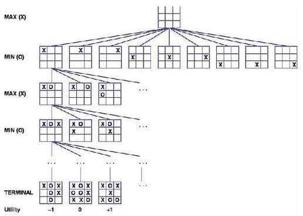

Comprendamos la terminología definida en términos del diagrama anterior.

- El estado inicial es la primera capa que define que el tablero está en blanco, es el turno de MAX para jugar.
- La función de sucesor enumera todos los movimientos sucesores posibles. Se define para todas las capas del árbol.
- El estado terminal es la última capa del árbol que muestra el estado final, es decir, si el jugador MAX gana, pierde o empata con el oponente.
- Las utilidades en este caso para los estados terminales son 1, 0 y -1 como se discutió anteriormente, y también pueden usarse para determinar las utilidades de los otros nodos.

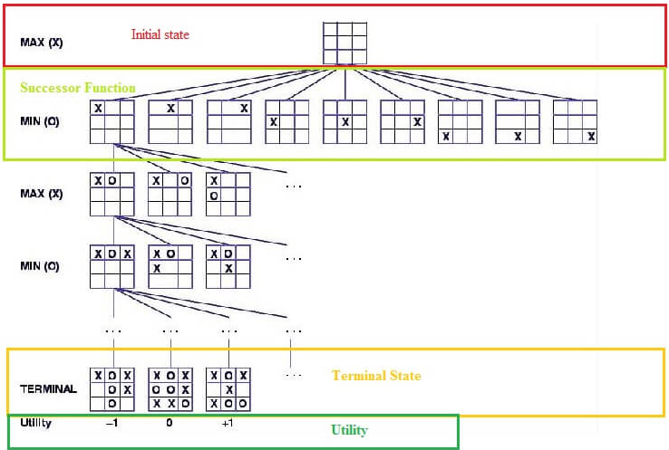

- Paso 2 : aplique la función de utilidad para obtener los valores de utilidad para todos los estados terminales.
- Paso 3 : Determine las utilidades de los nodos superiores con la ayuda de las utilidades de los nodos terminales. Por ejemplo, en el diagrama a continuación, tenemos las utilidades para los estados terminales escritas en los cuadrados.

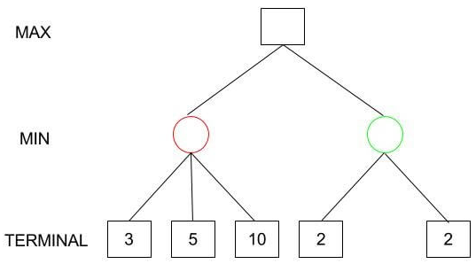

Calculemos la utilidad para el nodo izquierdo (rojo) de la capa sobre el terminal. Como es el movimiento del jugador MIN, elegiremos el mínimo de todas las utilidades. Para este caso, tenemos que evaluar MIN {3, 5, 10}, que sabemos que es ciertamente 3. Entonces, la utilidad para el nodo rojo es 3.

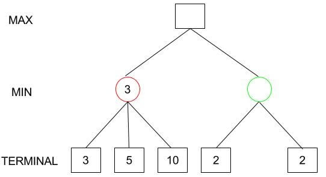

Del mismo modo, para el nodo verde en la misma capa, tendremos que evaluar MIN {2,2} que es 2.

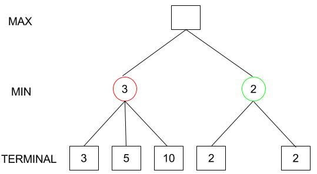

- Paso 4 : Calcule los valores de utilidad con la ayuda de hojas considerando una capa a la vez hasta la raíz del árbol.
- Paso 5 : Eventualmente, todos los valores respaldados llegan a la raíz del árbol, es decir, el punto más alto. En ese punto, MAX tiene que elegir el valor más alto.

En nuestro ejemplo, solo tenemos 3 capas, por lo que llegamos inmediatamente a la raíz, pero en los juegos reales, habrá muchas más capas y nodos. Entonces tenemos que evaluar MAX {3,2} que es 3.

Por lo tanto, el mejor movimiento de apertura para MAX es el nodo izquierdo (o el rojo). Este movimiento se llama la decisión minimax, ya que maximiza la utilidad después de la suposición de que el oponente también está jugando de manera óptima para minimizarlo.

Para resumir,

Decisión de Minimax = MAX {MIN {3,5,10}, MIN {2,2}}

= MAX {3,2}

= 3

#### Pseudocodigo:

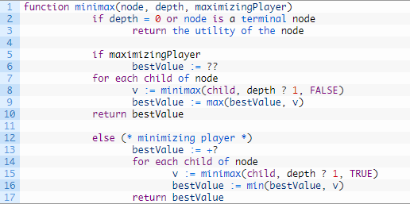

# Algoritmo Alfa-beta

La poda alfa beta es una optimización del algoritmo minimax, pues reduce el número de nodos evaluados en el árbol de juego de dicho algoritmo. Este tipo de algoritmo suele utilizarse para cualquier tipo de árbol de búsqueda en profundidad y para subárboles enteros. Este algoritmo al igual que el Minimax hace uso de la búsqueda en profundidad asi que para poder encontrar un resultado solo tendremos que considerar los nodos a lo largo de un solo camino. Entre las principales características que posee este algoritmo en comparación con el Minimax tenemos:

- Omisión de expansión de nodos que por sus valores no pueden ser los mejores.
- No afecta al resultado final.
- Permite búsquedas el doble de profundas que el Minimax
- Importancia de orden y no de valores exactos

Hay que tener en cuenta que para poder podar en un árbol que utiliza este algoritmo se debe recorrer el orden ya fijado, los valores de Max (Alfa) son los del límite inferior y los de Min (Beta) son los limites superiores. Esto quiere decir que en los niveles maximizantes solo Beta puede podar y en los niveles minimizantes solo alfa puede podar.

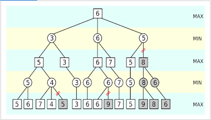

### Desarrollo del algoritmo

En la poda alfa-beta se utilizan dos parámetros que actuarán de cotas sobre el valor minimax de un nodo (α,β):

- Para un nodo MAX: α valor de la mejor elección para MAX (valor más alto) que hemos encontrado en el camino hasta ahora.
- Para un nodo MIN: β valor de la mejor elección para MIN (valor más bajo) que hemos encontrado en el camino hasta ahora.

El algoritmo actualiza los valores de a y B conforme se ejecuta, recorriendo el árbol.

¿En qué condiciones se realiza la poda? Sea v el valor de un nodo:

- Si el nodo es MAX y v ≥ β Se puede podar por debajo de dicho nodo.
- Si el nodo es MIN y v ≤ α Se puede podar por debajo del nodo.

### Eficiencia

La eficiencia de la poda Alfa-Beta depende del orden en el que se examinan los sucesores, es decir, el algoritmo se comportará de forma más eficiente si examinamos primero los mejores sucesores.

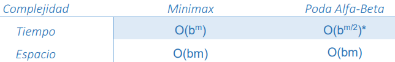

## Realizar una propuesta de cómo emplear el algoritmo en su problema del laberinto.

Asumiremos que nuestro laberinto está dividido en “cuadrados”. Cada cuadrado del laberinto está abierto u ocupado por una sección de pared. En este caso la figura a recorrer el laberinto sólo puede pasar a través de los cuadrados abiertos del laberinto. Si la figura se topa con una pared, debe intentar continuar en una dirección diferente. La figura requerirá un procedimiento sistemático para encontrar su salida del laberinto.

##### Aquí está el procedimiento:

- Desde nuestra posición de partida, primero intentaremos avanzar un cuadrado hacia el Norte y luego recursivamente probaremos nuestro procedimiento desde allí.
- Si no tenemos éxito al intentar un camino hacia el Norte como primer paso, daremos un paso hacia el Sur y repetiremos recursivamente nuestro procedimiento.
- Si ir hacia el Sur no funciona, entonces intentaremos dar un paso hacia el Oeste como nuestro primer paso y aplicaremos nuestro procedimiento recursivamente.
- Si el Norte, el Sur y el Oeste no han tenido éxito, aplicaremos el procedimiento recursivamente desde una posición un paso hacia nuestro Este.
- Si ninguna de estas direcciones funciona entonces no hay manera de salir del laberinto y hemos fracasado.

Eso suena bastante fácil, sin embargo hay un par de detalles que discutir primero. Supongamos que tomamos nuestro primer paso recursivo al ir hacia el Norte. Siguiendo nuestro procedimiento, nuestro próximo paso sería también hacia el Norte. Pero si el Norte está bloqueado por una pared debemos mirar el siguiente paso del procedimiento e intentar ir hacia el Sur. Desafortunadamente ese paso hacia el Sur nos lleva de regreso a nuestro lugar de partida original. Si aplicamos el procedimiento recursivo desde allí, simplemente regresaremos un paso hacia el Norte y estaremos en un ciclo infinito. Por lo tanto, debemos contar con una estrategia para recordar dónde hemos estado.

Para que nuestro programa funcione, necesitaremos contar con una manera de representar el laberinto. Para hacer esto aún más interesante vamos a utilizar el módulo turtle para dibujar y explorar nuestro laberinto de modo que podamos ver este algoritmo en acción. El objeto Laberinto proporcionará los siguientes métodos para que los usemos al escribir nuestro algoritmo de búsqueda:

- **init** lee en un archivo de datos que representa un laberinto, inicializa la representación interna del laberinto y encuentra la posición inicial para la tortuga.
- dibujarLaberinto dibuja el laberinto en una ventana en la pantalla.
- actualizarPosicion actualiza la representación interna del laberinto y cambia la posición de la tortuga en la ventana.
- esSalida comprueba si la posición actual es una salida del laberinto.

La clase Laberinto también sobrecarga el operador índice [] para que nuestro algoritmo pueda acceder fácilmente al estado de cualquier cuadrado particular.

Examinemos el código de la función de búsqueda que denominamos buscarDesde. Observe que esta función toma tres parámetros: un objeto laberinto, la fila de inicio y la columna de inicio. Esto es importante porque, como función recursiva, la búsqueda comienza lógicamente otra vez con cada llamada recursiva.

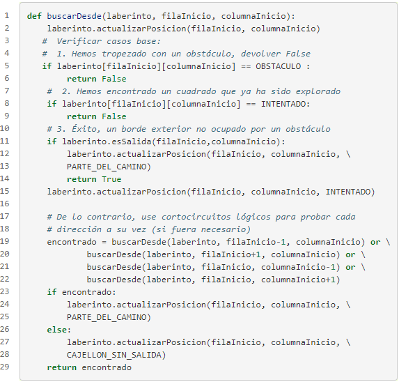

## Juego de PONG

```python
import pygame
import gym
import random
width=360
height=480
fps=30
white=(255,255,255)
black=(0,0,0)
red=(255,0,0)
green=(0,255,0)
blue=(0,0,255)
```

```python
class player1(pygame.sprite.Sprite):
    def __init__(self,x,y):
        pygame.sprite.Sprite.__init__(self)
        self.image=pygame.Surface((50,10))
        self.image.fill(green)
        self.image.set_colorkey(black)
        self.rect=self.image.get_rect()
        self.rect.centerx=x
        self.rect.bottom=y

    def update(self):
        self.speedx=0
        keystate=pygame.key.get_pressed()
        if keystate[pygame.K_LEFT]:
            self.speedx=-5
        if keystate[pygame.K_RIGHT]:
            self.speedx=5
        if self.rect.right>width:
            self.rect.right=width
        if self.rect.right<0:
            self.rect.left=0
        self.rect.x+=self.speedx
```

```python
class player2(pygame.sprite.Sprite):
    def __init__(self,x,y):
        pygame.sprite.Sprite.__init__(self)
        self.image=pygame.Surface((50,10))
        self.image.fill(green)
        self.image.set_colorkey(black)
        self.rect=self.image.get_rect()
        self.rect.centerx=x
        self.rect.bottom=y+10

    def update(self):
        self.speedx=0
        keystate=pygame.key.get_pressed()
        if keystate[pygame.K_a]:
            self.speedx=-5
        if keystate[pygame.K_d]:
            self.speedx=5
        if self.rect.right>width:
            self.rect.right=width
        if self.rect.right<0:
            self.rect.left=0
        self.rect.x+=self.speedx
```

```python
class Ball(pygame.sprite.Sprite):
    def __init__(self):
        pygame.sprite.Sprite.__init__(self)
        self.image=pygame.Surface((20,20))
        self.image.fill(white)
        self.image.set_colorkey(black)
        self.rect=self.image.get_rect()
        self.rect.centerx=width/3
        self.rect.bottom=height/2
        self.speedy=5
        self.speedx=0
    def update(self):
        self.rect.bottom+=self.speedy
        self.rect.centerx+=self.speedx
        if self.rect.bottom>height:
            self.speedy=-5
        if self.rect.top<0:
            self.speedy=5
        if self.rect.right>width or self.rect.centerx<-10:
            self.speedx=-self.speedx
    def deflect1(self,other):
        if self.rect.bottom<475:
            r=other.rect.centerx
            self.speedx=5*(180-r)/100 +random.randrange(-1,1)
            self.speedy=-self.speedy
    def deflect2(self,other):
        if self.rect.bottom>5:
            r=other.rect.centerx
            self.speedx=(-5)*(r-180)/100+random.randrange(-1,1)
            self.speedy=-self.speedy
```

```python
pygame.init()
pygame.mixer.init()
screen=pygame.display.set_mode((width,height))
pygame.display.set_caption("PONG")
clock=pygame.time.Clock()
all_sprites=pygame.sprite.Group()
balls=pygame.sprite.Group()
goodplayer=player1(0,480)
badplayer=player2(100,0)
ball=Ball()
all_sprites.add(goodplayer)
all_sprites.add(badplayer)
all_sprites.add(ball)
balls.add(ball)
running = True
count1=0
count2=0
while running:
    clock.tick(fps)
    for event in pygame.event.get():
        if event.type==pygame.QUIT:
            running=False
    all_sprites.update()
    hits1=pygame.sprite.spritecollide(goodplayer,balls,False)
    hits2=pygame.sprite.spritecollide(badplayer,balls,False)
    if hits1:
        ball.deflect1(goodplayer)
        count1+=1
    if hits2:
        ball.deflect2(badplayer)
        count2+=1
    if count1>count2+1000 or count2>count1+1000:
        running=False
    screen.fill(black)
    all_sprites.draw(screen)
    pygame.display.flip()
pygame.quit
```

```
<function pygame.base.quit>
```

```python
count1
```

```
49
```

```python
count2
```

```
45
```

[figure not shown]

## Referencias:

http://www.itnuevolaredo.edu.mx/takeyas/Apuntes/Inteligencia%20Artificial/Apuntes/tareas_alumnos/Minimax/Minimax(2005-II-A).pdf https://riuma.uma.es/xmlui/bitstream/handle/10630/12713/CristinaGomezGomezMemoriaTFG.pdf?sequence=1&isAllowed=y https://www.hackerearth.com/blog/developers/minimax-algorithm-alpha-beta-pruning/ http://iagermanicovp.blogspot.com/2015/11/el-algoritmo-minimax-y-poda-alfa-beta.html https://runestone.academy/runestone/static/pythoned/Recursion/ExploracionDeUnLaberinto.html